# JHU Data Science Capstone Intermediate Report - text prediction

Ying Yang

November 21, 2016

## Introduction

This capstone is to provide the prediction of the next words using the natual language processing techinque. This intermediate report provides data acquisition and cleaning, summary of the dataset, exploratory analysis, and the N-gram model fitting. The tool used in this project is R.

## Data acquisition and cleaning

The data used is provided by [SwiftKey](https://d396qusza40orc.cloudfront.net/dsscapstone/dataset/Coursera-SwiftKey.zip). The data is from a corpus called HC Corpora. You can find the detailed explaination on the corpora avaliable from [readme file](http://www.corpora.heliohost.org/aboutcorpus.html).

### Download the data

First, I download the data from the provided URL to my working directory

```r
setwd(".../10. Capstone")

fileDest <- "./Coursera-SwiftKey.zip"
fileURL <- "https://d396qusza40orc.cloudfront.net/dsscapstone/dataset/Coursera-SwiftKey.zip"
download.file(url = fileURL, destfile = fileDest)
unzip("Coursera-SwiftKey.zip")
```

### Load the data

```r
library(tm)

twitteData <- file("./final/en_US/en_US.twitter.txt", "r")
twitter <- readLines(twitteData, encoding = "UTF-8", skipNul=TRUE)
close(twitteData) # close the connection

blogsData <- file("./final/en_US/en_US.blogs.txt", "r")
blogs <- readLines(blogsData, encoding = "UTF-8", skipNul=TRUE)
close(blogsData)

newsData <- file("./final/en_US/en_US.news.txt", "r")
news <- readLines(newsData, encoding = "UTF-8", skipNul=TRUE)
close(newsData)
```

### Summary Statistics

Then I provide the summary statistics of the data files, including the size, number of the lines, the length in characters of the longest lines, and the number of words of each dataset. A simple table is generated.

```r
library(R.utils)
# this is to use the linux command, wc -L filename
# wc -L <filename> prints the length of longest line (GNU extension)

dataSummary <- data.frame()
dataSummary[1,1] <- "twitter"
dataSummary[2,1] <- "blogs"
dataSummary[3,1] <- "news"

# find out the size of each file
dataSummary[1,2] <- file.info("./final/en_US/en_US.twitter.txt")$size / (1024*1024)
dataSummary[2,2] <- file.info("./final/en_US/en_US.blogs.txt")$size / (1024*1024)
dataSummary[3,2] <- file.info("./final/en_US/en_US.news.txt")$size / (1024*1024)

# find out the number of lines in each file
dataSummary[1,3] <- as.numeric(gsub("[^0-9]", "",
                                    system2("wc", args = "-l ./final/en_US/en_US.twitter.txt",
                                                          stdout=TRUE)))
dataSummary[2,3] <- as.numeric(gsub("[^0-9]", "",
                                    system2("wc", args = "-l ./final/en_US/en_US.blogs.txt",
                                                          stdout=TRUE)))
dataSummary[3,3] <- as.numeric(gsub("[^0-9]", "",
                                    system2("wc", args = "-l ./final/en_US/en_US.news.txt",
                                                          stdout=TRUE)))
# count the longest line in characters
dataSummary[1,4] <- as.numeric(gsub("[^0-9]", "",
                                    system2("wc", args = "-L ./final/en_US/en_US.twitter.txt",
                                                          stdout=TRUE)))
dataSummary[2,4] <- as.numeric(gsub("[^0-9]", "",
                                    system2("wc", args = "-L ./final/en_US/en_US.blogs.txt",
                                                          stdout=TRUE)))
dataSummary[3,4] <- as.numeric(gsub("[^0-9]", "",
                                    system2("wc", args = "-L ./final/en_US/en_US.news.txt",
                                                          stdout=TRUE)))
# count the words
dataSummary[1,5] <- as.numeric(gsub("[^0-9]", "",
                                    system2("wc", args = "-w ./final/en_US/en_US.twitter.txt",
                                                          stdout=TRUE)))
dataSummary[2,5] <- as.numeric(gsub("[^0-9]", "",
                                    system2("wc", args = "-w ./final/en_US/en_US.blogs.txt",
                                                          stdout=TRUE)))
dataSummary[3,5] <- as.numeric(gsub("[^0-9]", "",
                                    system2("wc", args = "-w ./final/en_US/en_US.news.txt",
                                                          stdout=TRUE)))

names(dataSummary) <- c("name","fileSize", "lineLength", "longestLine", "wordsCount")

dataSummary
```

```
##      name fileSize lineLength longestLine wordsCount
## 1 twitter 159.3641    2360148         140   30341028
## 2   blogs 200.4242     899288       40832   37272578
## 3    news 196.2775    1010243       11384   34309642
```

### Generate a random sample

To reiterate, to build models you don’t need to load in and use all of the data. Often relatively few randomly selected rows or chunks need to be included to get an accurate approximation to results that would be obtained using all the data.

I then randomly generate 20% data lines from the original datasets (twitter, blogs, and news) and write it out to a separate file after the data cleaning. In this way, we don’t need to recreate it everytime.

```r
## Generating a random sapmle of all sources
set.seed(123456)
prop = 0.2
sampleTwitter <- twitter[sample(1:length(twitter),prop*length(twitter))]
sampleBlogs <- blogs[sample(1:length(blogs),prop*length(blogs))]
sampleNews <- news[sample(1:length(news),prop*length(news))]

sampleD <- c(sampleTwitter,sampleNews,sampleBlogs)
```

### Data cleaning

Next, I cleaned the text data in the following steps

- remove words with non-ASCII characters
- convert it to lower cases
- remove stop words
- remove punctuation
- remove extra white spaces
- remove number
- remove URL
- remove websites
- remove email
- remove profanity words
- word stemming

When modeling and predicting the text words, some steps may not be necessary, we may consider not doing them, such as removing stopwords and word stemming.

To remove profanity words fromt he dataset, I otained the profanity words list from (http://www.freewebheaders.com/wordpress/wp-content/uploads/full-list-of-bad-words-banned-by-google-txt-file.zip) and downloaded into my working directory and loaded the data.

```r
## load the profanity words
profanity <- file("profanitywords.txt", "r")
profanityFilter <- readLines(profanity, encoding = "UTF-8", skipNul=TRUE)
profanityFilter <- iconv(profanityFilter,"latin1","ASCII",sub = "")
close(profanity)
```

```r
## create a function cleanCorpus to clean the dataset
cleanCorpus <- function(originalData, profanityFilter){
        #' remove words with non-ASCII characters
        data <- iconv(originalData,"latin1","ASCII",sub = " ")
        # Convert it to Corpus
        proData <- Corpus(VectorSource(data))
        #' Convert it to lower cases
        proData <- tm_map(proData, content_transformer(tolower))
        #' Remove stop words  ### This might be optional
        proData <- tm_map(proData, removeWords, stopwords("english"))
        #' Remove punctuation
        proData <- tm_map(proData, removePunctuation)
        #' Remove extra white spaces
        proData <- tm_map(proData, stripWhitespace)
        #' Remove number
        proData <- tm_map(proData, removeNumbers)
        # Remove URL
        urlExp <- "(f|ht)tp\\S+\\s*"  # \\S mataches anything but a white space. \\s matches white space
        removeUrl <- function(x) gsub(urlExp, "", x)
        proData <- tm_map(proData, content_transformer(removeUrl))
        # Remove websites
        webExp <- "www\\S+\\s*"
        removeWeb <- function(x) gsub(webExp, "", x)
        proData <- tm_map(proData, content_transformer(removeWeb))
        #' Remove email
        emailExp <- "[a-z]+@[a-z]+[.][a-z.]+"
        removeEmail <- function(x) gsub(emailExp, "", x)
        proData <- tm_map(proData, content_transformer(removeEmail))
        #' Remove profanity words
        proData <- tm_map(proData, removeWords, profanityFilter)
        #' initiate steming   (e.g. doing ->  do)  ### This might be optional
        proData <- tm_map(proData, stemDocument)
        proData
}
```

```r
sampleData <- cleanCorpus(sampleD, profanityFilter)
save(sampleData, file = "finalSampleCorpus.RData")
```

## Build N-grams for the tokenized data

[N-grams](https://en.wikipedia.org/wiki/N-gram) are created to explore word frequencies. An n-gram of size 1 is referred to as a “unigram”; size 2 is a “bigram” (or, less commonly, a “digram”); size 3 is a “trigram”. Larger sizes are sometimes referred to by the value of n, e.g., “four-gram”, “five-gram”, and so on.

In this project, I’ve created unigram, bigram, trigram, and fourgram for preparing the prediction.

```r
#'
#' Using the tidytext package, create unigrams, bigrams and trigrams are created.
library(stringr)
library(tidytext)
library(dplyr)  # count

tokenizedNgrams <- function(corpusData, n){
        # convert it to data frame
        df <- as.data.frame(unlist(
                lapply(corpusData[1:length(content(corpusData))], as.character)))
        names(df) <- "text"

        # Build N-grams
        ngram <- df %>%
                unnest_tokens(word, text, token = "ngrams", n=n)
}
```

```r
# create n-grams for 20% of the sample
unigramS  <- tokenizedNgrams(sampleData, 1)
bigramS   <- tokenizedNgrams(sampleData, 2)
trigramS  <- tokenizedNgrams(sampleData, 3)
fourgramS <- tokenizedNgrams(sampleData, 4)
```

## Expoloratory analysis

In the exploratory analysis, I first calculate the frequency of the words appeared in each N-gram model.

```r
# create a function to calcuate the frequency of ngram models
wordFreq <- function(ngram, maxWords){
    ngram <- ngram %>% count(word)
    m <- (dim(ngram))[1]
    names(ngram) <- c("word", "instance")
    ngram <- as.data.frame(ngram)
    # sort by word (ascending) and instance (descending)
    ngram <- ngram[order(-ngram$instance, ngram$word),]
    # cumulative instance of the words
    ngram$cumInstance  <- cumsum(ngram$instance)
    # frequency of the words
    ngram$frequency    <- ngram$instance/ngram$cumInstance[m]*100
    # cumulartive frequency of the word
    ngram$cumFrequency <- ngram$cumInstance/ngram$cumInstance[m]*100
    ngram$id <- 1:m
    return(ngram)
}
# Generate the word frequency for each ngram models and save it.
unigramS  <- wordFreq(unigramS)
bigramS   <- wordFreq(bigramS)
trigramS  <- wordFreq(trigramS)
quadgramS <- wordFreq(quadgramS)
save(unigramS, bigramS, trigramS, quadgramS, file = "sampleNgrams.RData")
```

If we look closer to the word frequency table, we find that only 0.26% unique words are needed to cover 50% of all word instances in the unigram under this sample data. To cover 90% of all words, only 3.62% unique words are needed. As the size of the ngram increases, the number of words needed to cover half of all phrase instances also dramatically increases. Starting from trigram, the frequency of the phrases seems are almost evenly spreaded. This indicates that if we want to use a n-gram with higher size, we need to include a large amount of parameters in order to cover a large vocabulary. To make the model more efficient, we will not use four-gram in the prediction analysis.

```r
####################### some interesting findings #########################
#' How many unique words do you need in a frequency sorted dicionary over
#' 50% of all word instances in the language?
tbl <- data.frame("Ngram" = c("Unigram", "Bigram", "Trigram", "Four-gram"),
                  "sampleLength" = c(dim(unigramS)[1], dim(bigramS)[1], dim(trigramS)[1], dim(fourgramS)[1]))
tbl$'50Coverage' <- c((min(unigramS$id[which(unigramS$cumFrequency > 50)])),
                      (min(bigramS$id[which(bigramS$cumFrequency > 50)])),
                      (min(trigramS$id[which(trigramS$cumFrequency > 50)])),
                      (min(fourgramS$id[which(fourgramS$cumFrequency > 50)])))
tbl$'50CovRate' <- tbl$'50Coverage'/tbl$sampleLength*100
tbl$'90Coverage' <- c((min(unigramS$id[which(unigramS$cumFrequency > 90)])),
                      (min(bigramS$id[which(bigramS$cumFrequency > 90)])),
                      (min(trigramS$id[which(trigramS$cumFrequency > 90)])),
                      (min(fourgramS$id[which(fourgramS$cumFrequency > 90)])))
tbl$'90CovRate' <- tbl$'90Coverage'/tbl$sampleLength*100
tbl$'90CovRate' <- round(tbl$'90CovRate', 2)
tbl$'50CovRate' <- round(tbl$'50CovRate', 2)
tbl
```

```
##       Ngram sampleLength 50Coverage 50CovRate 90Coverage 90CovRate
## 1   Unigram       192819        492      0.26       6980      3.62
## 2    Bigram      3683790     400689     10.88    2934812     79.67
## 3   Trigram      7023486    3278596     46.68    6274508     89.34
## 4 Four-gram      7427413    3682523     49.58    6678435     89.92
```

The distribution of the word frequencies from unigram, bigram, and trigram are plotted.

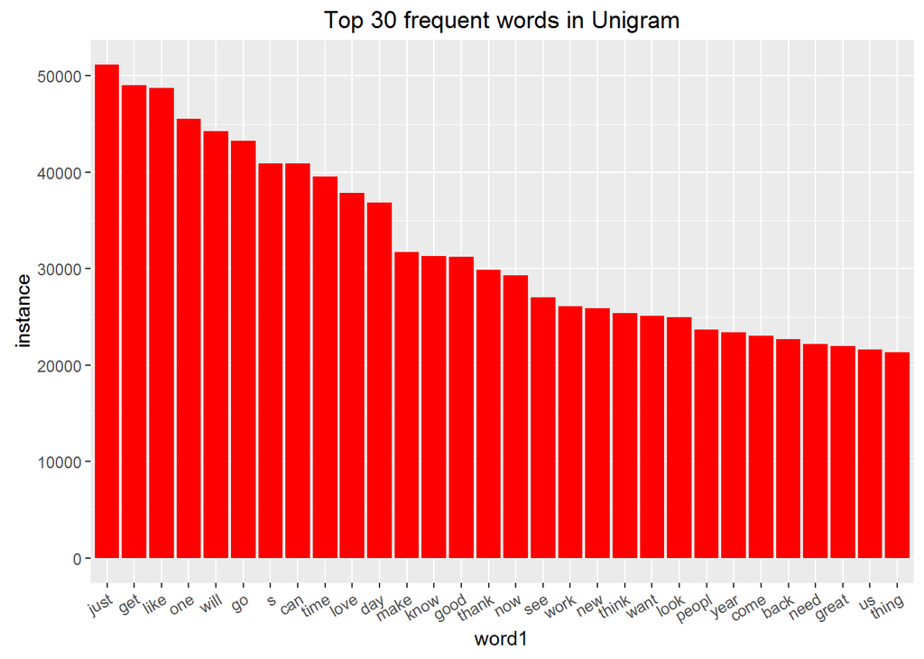

```r
library(ggplot2)
frequencyGraph <- function(data, n, ngramName, color){
  a <- data[1:n,]
  a$word1 <-factor(a$word, levels=a[order(a$instance, decreasing = TRUE), "word"])
  ggplot(a, aes(y=instance, x=word1)) +
    geom_bar(stat="identity", fill= color) +
    ggtitle(paste("Top", n, "frequent words in", ngramName)) +
    theme(axis.text.x = element_text(angle=30, hjust=1))

}
frequencyGraph(unigramS, 30, "Unigram", "red")
```

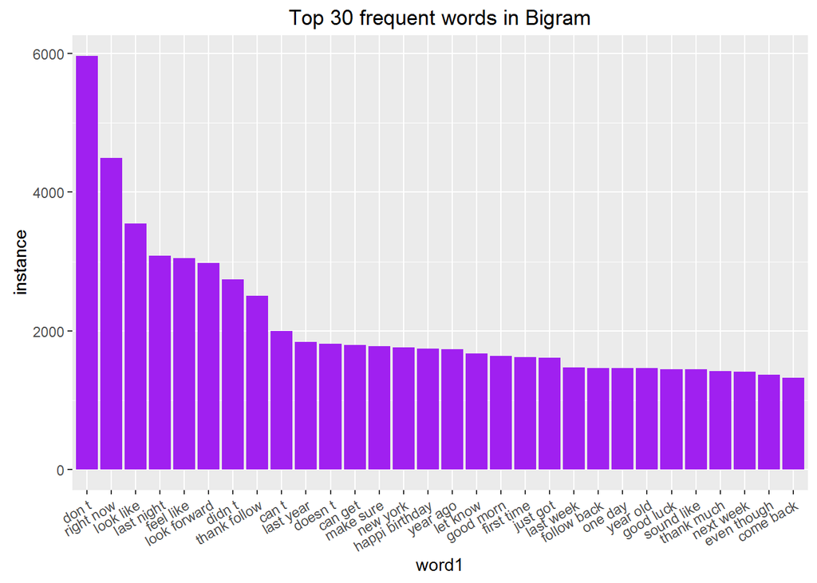

```r
frequencyGraph(bigramS, 30, "Bigram", "purple")
```

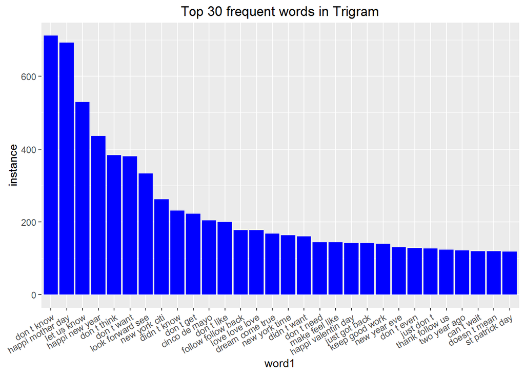

```r
frequencyGraph(trigramS, 30, "Trigram", "blue")
```

Next, the wordclouds of the ngrams are plotted.

```r
# word cloud
library(wordcloud, quietly = TRUE)
wordcloud(unigramS$word, unigramS$instance, max.words = 100, colors=brewer.pal(8, "Dark2"))
wordcloud(bigramS$word,  bigramS$instance,  max.words = 80, colors=brewer.pal(8, "Dark2"))
wordcloud(trigramS$word, trigramS$instance, max.words = 80, colors=brewer.pal(8, "Dark2"))
```

Word cloud for the first 100 words in unigram

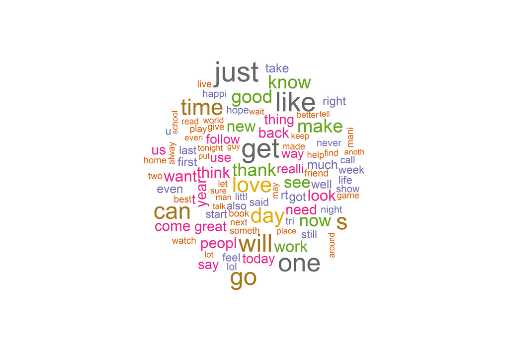

Word cloud for the first 80 words in bigram

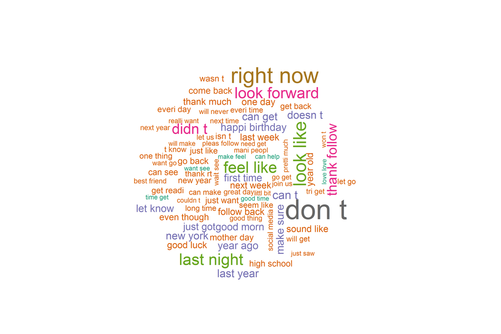

Word cloud for the first 80 words in trigram

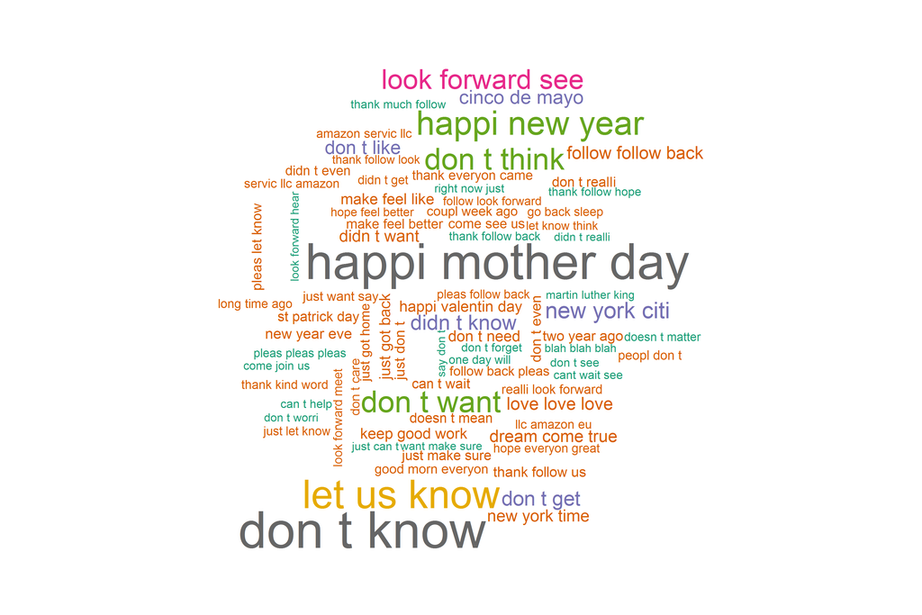

## Future plan

The next step in this project would be build a predictive model based on the N-grams. To smooth the unobserved probability, I plan to use the Naive backoff model in the predictio model. There is a trade off between efficiency and accuracy. By selecting a larger number of parameters, namely including more phrases will increase the accuracy, but decrease the model efficiency. Therefore, I plan to try to select different number of parameters. Finally, I will create an application for text prediction, in which user can type a word and the App will predict the next word. A presentation slide will be created to highlight the product.